# Salaries - Case Study

Shajakhan Yacob Ali

#### $\color{Red}{\text{Loading required packages}}$

```r
library(car)
library(tidyverse)
library(ggrepel)
library(broom)
library(caret)
library(rpart)
library(rpart.plot)
library(pROC)
```

#### $\color{red}{\text{Exploratory Data Analysis}}$

```r
Salaries <- as.tbl(Salaries)
str(Salaries)
```

```
Classes 'tbl_df', 'tbl' and 'data.frame':   397 obs. of  6 variables:
 $ rank         : Factor w/ 3 levels "AsstProf","AssocProf",..: 3 3 1 3 3 2 3 3 3 3 ...
 $ discipline   : Factor w/ 2 levels "A","B": 2 2 2 2 2 2 2 2 2 2 ...
 $ yrs.since.phd: int  19 20 4 45 40 6 30 45 21 18 ...
 $ yrs.service  : int  18 16 3 39 41 6 23 45 20 18 ...
 $ sex          : Factor w/ 2 levels "Female","Male": 2 2 2 2 2 2 2 2 2 1 ...
 $ salary       : int  139750 173200 79750 115000 141500 97000 175000 147765 119250 129000 ...
```

```r
summary(Salaries)
```

```
        rank     discipline yrs.since.phd    yrs.service        sex
 AsstProf : 67   A:181      Min.   : 1.00   Min.   : 0.00   Female: 39
 AssocProf: 64   B:216      1st Qu.:12.00   1st Qu.: 7.00   Male  :358
 Prof     :266              Median :21.00   Median :16.00
                            Mean   :22.31   Mean   :17.61
                            3rd Qu.:32.00   3rd Qu.:27.00
                            Max.   :56.00   Max.   :60.00
     salary
 Min.   : 57800
 1st Qu.: 91000
 Median :107300
 Mean   :113706
 3rd Qu.:134185
 Max.   :231545
```

#### $\color{green}{\text{Checking for Missing Values}}$

```r
map_dbl(Salaries, function(x) sum(is.na(x)))
```

```
         rank    discipline yrs.since.phd   yrs.service           sex
            0             0             0             0             0
       salary
            0
```

#### $\color{green}{\text{Salary Distribution}}$

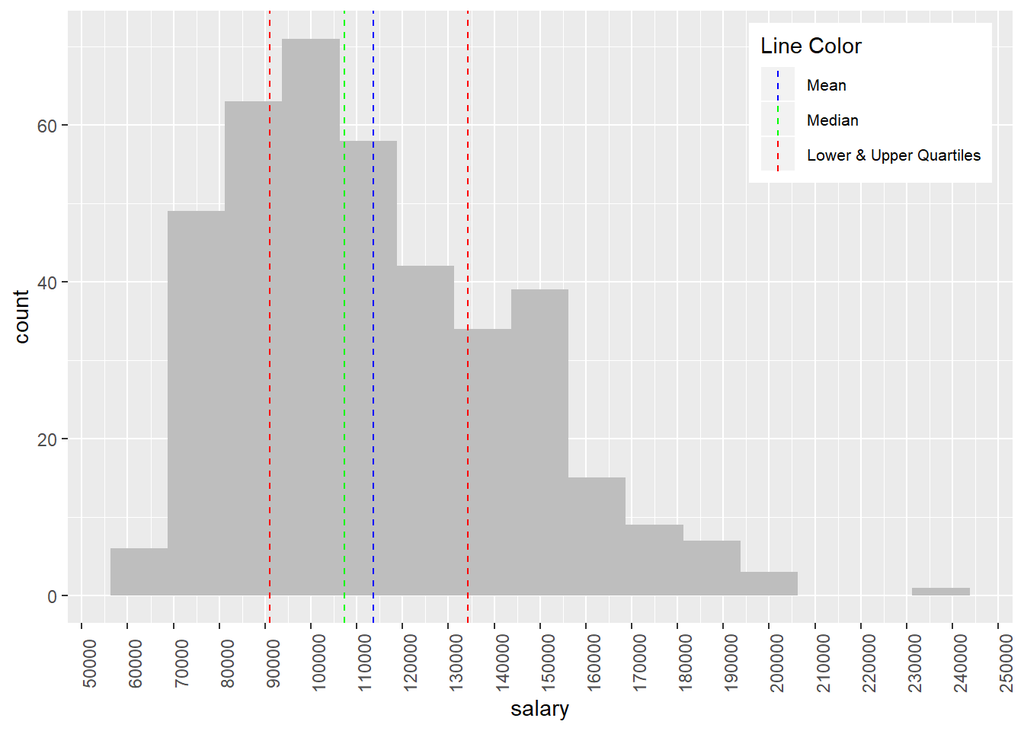

```r
Salaries %>%
  ggplot(aes(salary)) +
  geom_histogram(binwidth = 12500, fill = "grey") +
  geom_vline(aes(xintercept = mean(Salaries$salary), col = "blue"), linetype = 2) +
  geom_vline(aes(xintercept = median(Salaries$salary), col = "green"), linetype = 2) +
  geom_vline(aes(xintercept = quantile(Salaries$salary, 0.25), col = "red"), linetype = 2) +
  geom_vline(aes(xintercept = quantile(Salaries$salary, 0.75), col = "red"), linetype = 2) +
  scale_color_manual("Line Color", values = c("blue" = "blue", "green" = "green", "red" = "red"),
                     labels = c("Mean", "Median", "Lower & Upper Quartiles")) +
  scale_x_continuous(breaks = seq(50000, 250000, 10000)) +
  theme(legend.position = c(0.85, 0.85),
        legend.text=element_text(size=8),
        axis.text.x = element_text(angle = 90))
```

```r
Salaries %>%
  arrange(desc(salary))
```

```
# A tibble: 397 x 6
   rank  discipline yrs.since.phd yrs.service sex   salary
   <fct> <fct>              <int>       <int> <fct>  <int>
 1 Prof  B                     38          38 Male  231545
 2 Prof  A                     43          43 Male  205500
 3 Prof  A                     29           7 Male  204000
 4 Prof  A                     42          18 Male  194800
 5 Prof  B                     26          19 Male  193000
 6 Prof  B                     49          60 Male  192253
 7 Prof  B                     34          33 Male  189409
 8 Prof  B                     56          49 Male  186960
 9 Prof  A                     33          18 Male  186023
10 Prof  A                     39           9 Male  183800
# ... with 387 more rows
```

#### $\color{green}{\text{Salary by different Categorical Variables}}$

##### $\color{blue}{\text{Salary by rank}}$

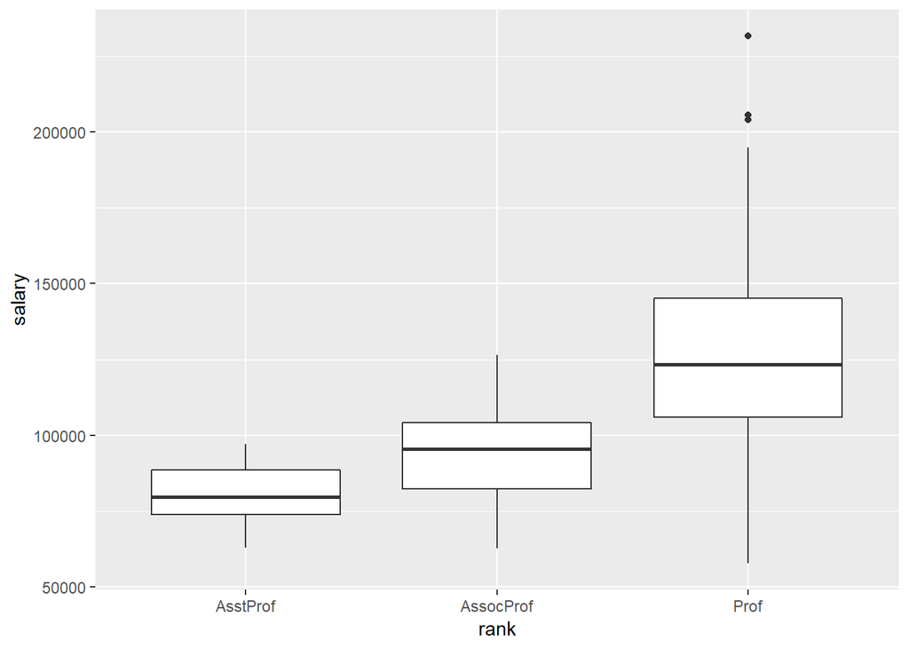

```r
Salaries %>%
  ggplot(aes(rank, salary)) +
  geom_boxplot()
```

##### $\color{blue}{\text{Salary by discipline}}$

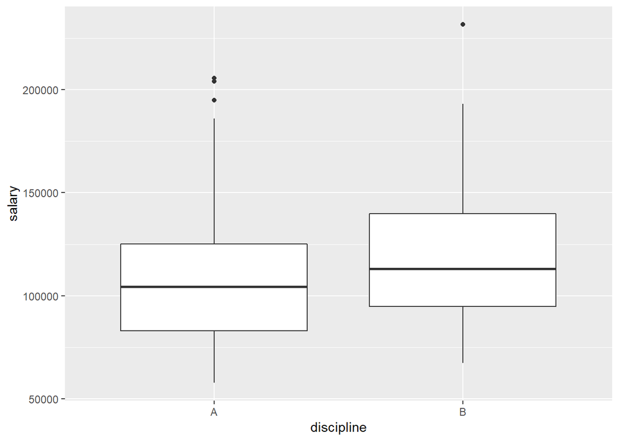

```r
Salaries %>%
  ggplot(aes(discipline, salary)) +
  geom_boxplot()
```

##### $\color{blue}{\text{Salary by sex}}$

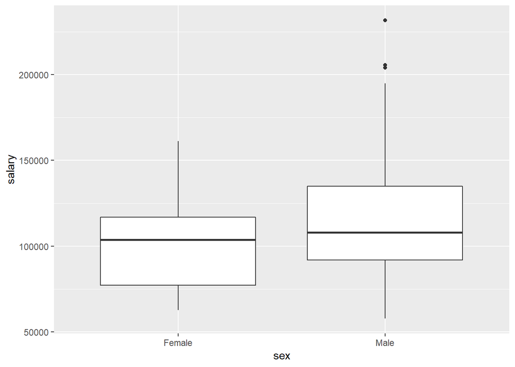

```r
Salaries %>%
  ggplot(aes(sex, salary)) +
  geom_boxplot()
```

##### $\color{blue}{\text{Salary by rank, sex and discipline}}$

```r
# Frequency Table
Salaries %>%
  group_by(sex, rank, discipline) %>%
  count()
```

```
# A tibble: 12 x 4
# Groups:   sex, rank, discipline [12]
   sex    rank      discipline     n
   <fct>  <fct>     <fct>      <int>
 1 Female AsstProf  A              6
 2 Female AsstProf  B              5
 3 Female AssocProf A              4
 4 Female AssocProf B              6
 5 Female Prof      A              8
 6 Female Prof      B             10
 7 Male   AsstProf  A             18
 8 Male   AsstProf  B             38
 9 Male   AssocProf A             22
10 Male   AssocProf B             32
11 Male   Prof      A            123
12 Male   Prof      B            125
```

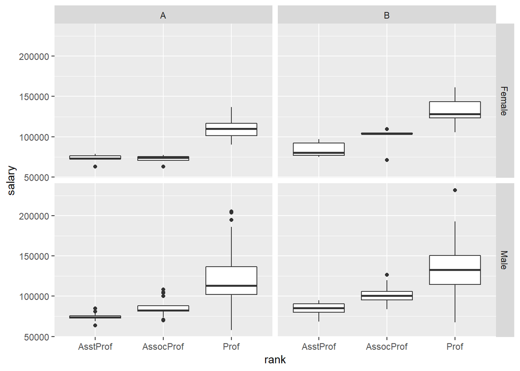

```r
Salaries %>%
  ggplot(aes(rank, salary)) +
  geom_boxplot() +
  facet_grid(sex ~ discipline)
```

#### $\color{green}{\text{Salary vs Continuous Variables}}$

##### $\color{blue}{\text{salary vs yrs.since.phd}}$

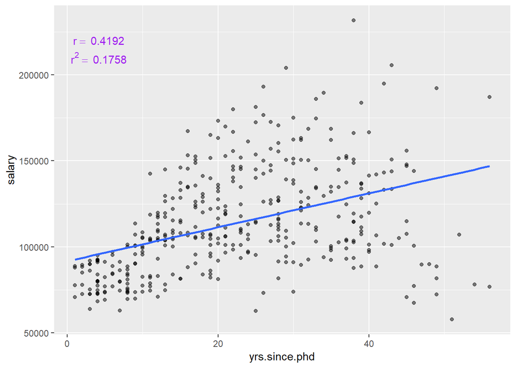

```r
ggplot(Salaries, aes(yrs.since.phd, salary)) +
  geom_point(alpha = 0.5) +
  geom_smooth(method = "lm", se = FALSE) +
  annotate("text", x = 4, y = 220000, parse = TRUE, col = "purple",
           label = str_c("~r ==~", round(cor(Salaries$yrs.since.phd, Salaries$salary), 4))) +
  annotate("text", x = 4, y = 210000, parse = TRUE, col = "purple",
           label = str_c("~r^2==~", round(cor(Salaries$yrs.since.phd, Salaries$salary) ^ 2, 4)))
```

##### $\color{blue}{\text{salary vs yrs.since.phd by rank & discipline}}$

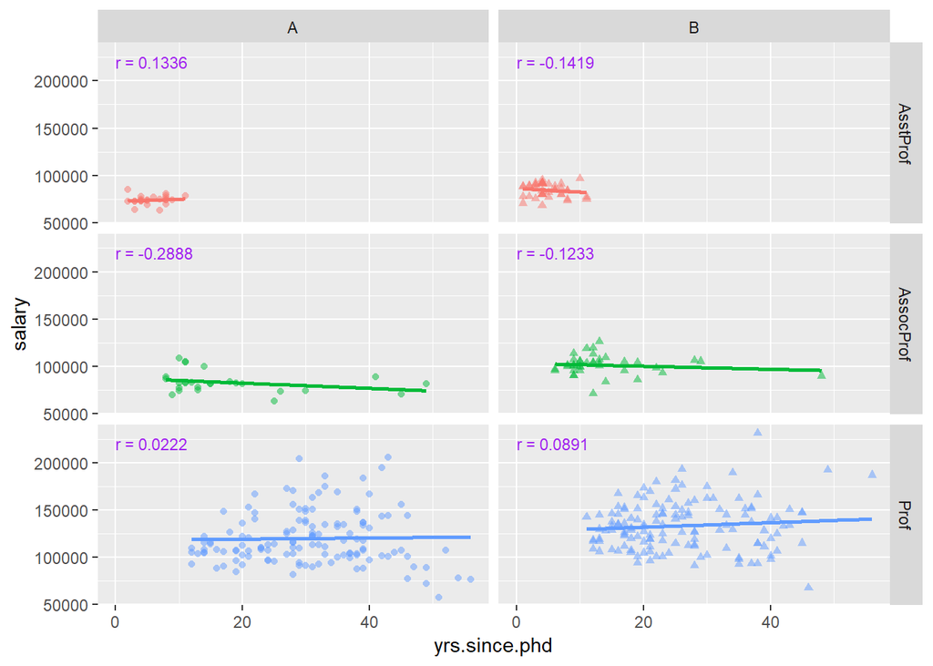

```r
Salaries %>%
  group_by(discipline, rank) %>%
  summarise(cor = round(cor(yrs.since.phd, salary), 4)) %>%
  mutate(cor = str_c("r = ", cor)) %>%
  as.data.frame() -> cor_yrs.since.phd_salary

ggplot(Salaries, aes(yrs.since.phd, salary, col = rank, shape = discipline)) +
  geom_point(alpha = 0.5) +
  geom_smooth(method = "lm", se = FALSE) +
  facet_grid(rank ~ discipline) +
  geom_text(data = cor_yrs.since.phd_salary, aes(x = 0, y = 220000, label = cor),
            hjust = "inward", size = 3, col = "purple", inherit.aes = FALSE) +
  theme(legend.position = "none")
```

##### $\color{blue}{\text{salary vs yrs.service}}$

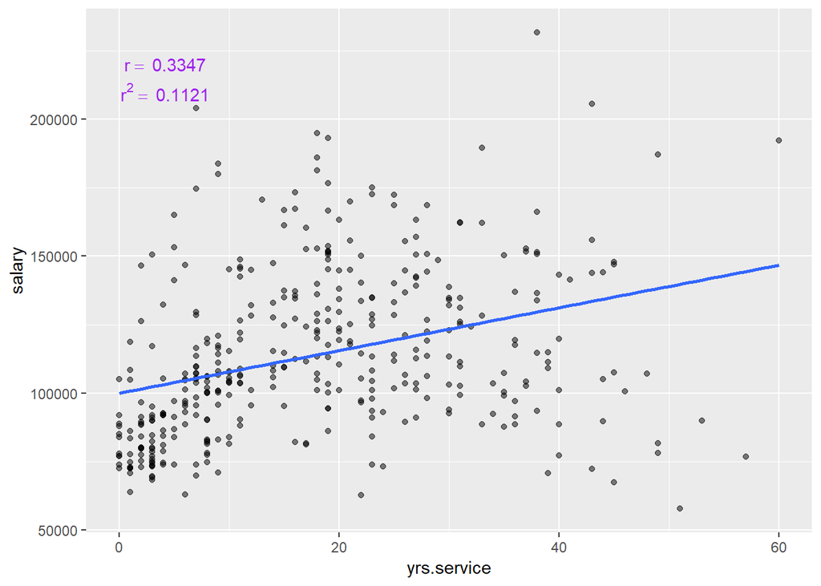

```r
ggplot(Salaries, aes(yrs.service, salary)) +
  geom_point(alpha = 0.5) +
  geom_smooth(method = "lm", se = FALSE) +
  annotate("text", x = 4, y = 220000, parse = TRUE, col = "purple",
           label = str_c("~r ==~", round(cor(Salaries$yrs.service, Salaries$salary), 4))) +
  annotate("text", x = 4, y = 210000, parse = TRUE, col = "purple",
           label = str_c("~r^2==~", round(cor(Salaries$yrs.service, Salaries$salary) ^ 2, 4)))
```

##### $\color{blue}{\text{Salary vs yrs.service by rank & discipline}}$

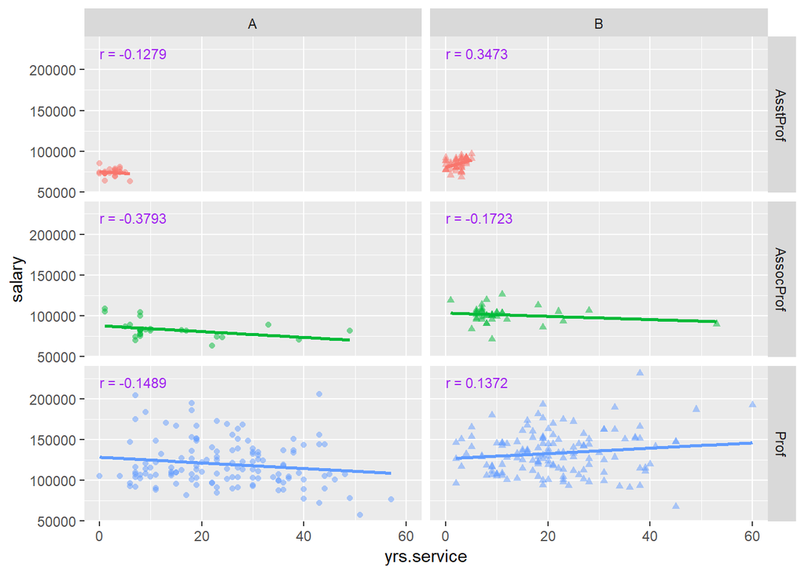

```r
Salaries %>%
  group_by(discipline, rank) %>%
  summarise(cor = round(cor(yrs.service, salary), 4)) %>%
  mutate(cor = str_c("r = ", cor)) %>%
  as.data.frame() -> cor_yrs.service_salary

ggplot(Salaries, aes(yrs.service, salary, col = rank, shape = discipline)) +
  geom_point(alpha = 0.5) +
  geom_smooth(method = "lm", se = FALSE) +
  facet_grid(rank ~ discipline) +
  geom_text(data = cor_yrs.service_salary, aes(x = 0, y = 220000, label = cor),
            hjust = "inward", size = 3, col = "purple", inherit.aes = FALSE) +
  theme(legend.position = "none")
```

##### $\color{green}{\text{yrs.service vs yrs.since.phd}}$

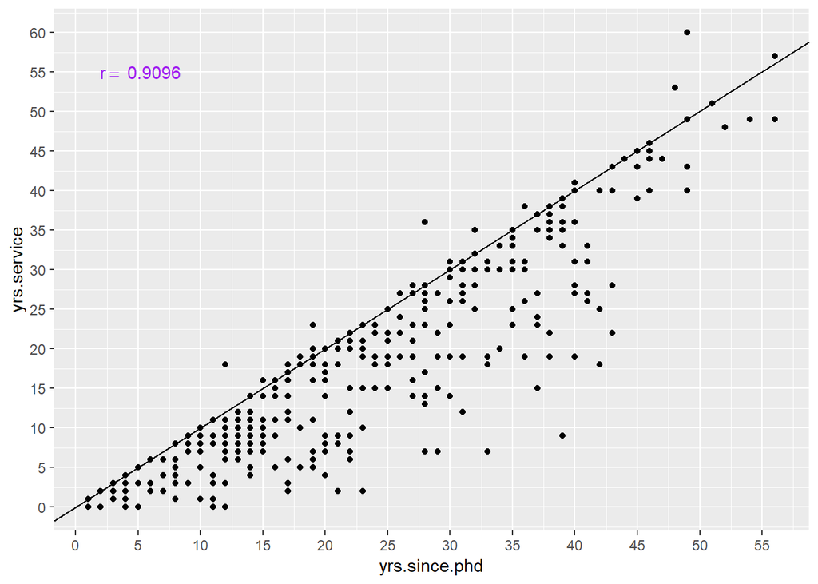

```r
ggplot(Salaries, aes(yrs.since.phd, yrs.service))+
  geom_point()+
  scale_x_continuous(breaks = seq(0,60,5)) +
  scale_y_continuous(breaks = seq(0,65,5)) +
  geom_abline(slope =1, intercept=0) +
  annotate("text", x = 5, y = 55, parse = TRUE, col = "purple",
           label = str_c("~r ==~", round(cor(Salaries$yrs.since.phd, Salaries$yrs.service), 4)))
```

#### $\color{Red}{\text{Analysis Task}}$

##### 1. What percentage of records are Assistant Professors with less than 5 years of experience?

```r
mean(Salaries$rank == "AsstProf" & Salaries$yrs.service < 5)
```

```
[1] 0.1586902
```

$\color{green}{\text{15.87% of records are Assistant Professors with less than 5 years of experience}}$

##### 2. Is there a statistically significant difference between female and male salaries?

```r
wilcox.test(salary ~ sex, data = Salaries)
```

```
    Wilcoxon rank sum test with continuity correction

data:  salary by sex
W = 5182.5, p-value = 0.008237
alternative hypothesis: true location shift is not equal to 0
```

$\color{green}{\text{p-value of 0.008237 confirms that the difference in Male and Female salaries are statistically significant}}$

##### 3. What is the distribution of salary by rank and discipline?

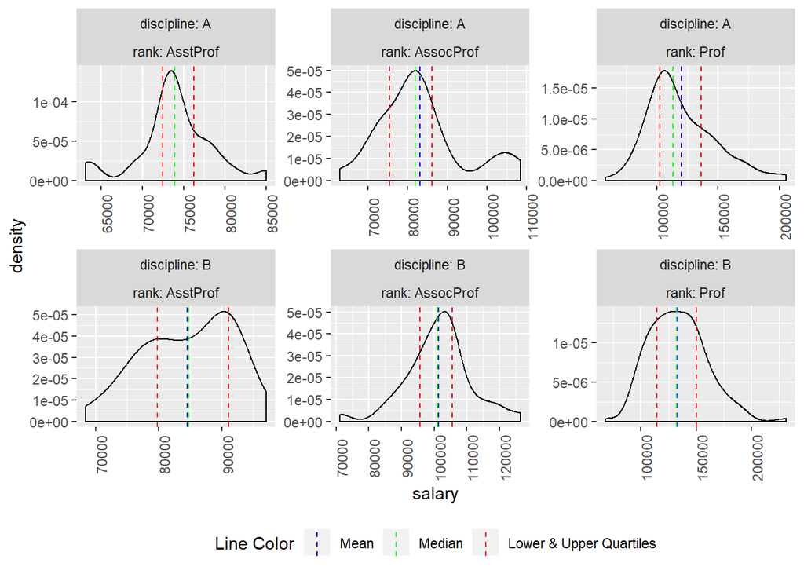

```r
Salaries %>%
  group_by(discipline, rank) %>%
  mutate(Minimum = min(salary),
         Lower_Quartile = quantile(salary, 0.25),
         Median = median(salary),
         Mean = mean(salary),
         Upper_Quartile = quantile(salary, 0.75),
         Maximum = max(salary)) %>%
  ggplot(aes(salary, group = interaction(discipline, rank))) +
  geom_density() +
  geom_vline(aes(xintercept = Mean, col = "blue"), linetype = 2) +
  geom_vline(aes(xintercept = Median, col = "green"), linetype = 2) +
  geom_vline(aes(xintercept = Lower_Quartile, col = "red"), linetype = 2) +
  geom_vline(aes(xintercept = Upper_Quartile, col = "red"), linetype = 2) +
  facet_wrap(discipline ~ rank, scales = "free", labeller = label_context) +
  scale_color_manual("Line Color", values = c("blue" = "blue", "green" = "green", "red" = "red"),
                     labels = c("Mean", "Median", "Lower & Upper Quartiles")) +
  theme(axis.text.x = element_text(angle = 90),
        legend.position = "bottom")
```

##### 4. How would you recode discipline as a 0/1 binary indicator?

```r
Salaries %>%
  mutate(row = row_number(),
         discipline = str_c("discipline_",discipline),
         value = 1) %>%
  spread(discipline, value, fill = 0) %>%
  select(-row) %>%
  str()
```

```
Classes 'tbl_df', 'tbl' and 'data.frame':   397 obs. of  7 variables:
 $ rank         : Factor w/ 3 levels "AsstProf","AssocProf",..: 3 3 1 3 3 2 3 3 3 3 ...
 $ yrs.since.phd: int  19 20 4 45 40 6 30 45 21 18 ...
 $ yrs.service  : int  18 16 3 39 41 6 23 45 20 18 ...
 $ sex          : Factor w/ 2 levels "Female","Male": 2 2 2 2 2 2 2 2 2 1 ...
 $ salary       : int  139750 173200 79750 115000 141500 97000 175000 147765 119250 129000 ...
 $ discipline_A : num  0 0 0 0 0 0 0 0 0 0 ...
 $ discipline_B : num  1 1 1 1 1 1 1 1 1 1 ...
```

#### $\color{red}{\text{Build a predictive model using salary as the response}}$

##### $\color{blue}{\text{Linear Model 1}}$

```r
linear_mod_1 <- lm(salary ~ . -sex, data = Salaries)
summary(linear_mod_1)
```

```
Call:
lm(formula = salary ~ . - sex, data = Salaries)

Residuals:
   Min     1Q Median     3Q    Max
-65244 -13498  -1455   9638  99682

Coefficients:
              Estimate Std. Error t value Pr(>|t|)
(Intercept)    69869.0     3332.1  20.968  < 2e-16 ***
rankAssocProf  12831.5     4147.7   3.094  0.00212 **
rankProf       45287.7     4236.7  10.689  < 2e-16 ***
disciplineB    14505.2     2343.4   6.190 1.52e-09 ***
yrs.since.phd    534.6      241.2   2.217  0.02720 *
yrs.service     -476.7      211.8  -2.250  0.02497 *
---
Signif. codes:  0 '***' 0.001 '**' 0.01 '*' 0.05 '.' 0.1 ' ' 1

Residual standard error: 22550 on 391 degrees of freedom
Multiple R-squared:  0.4525,    Adjusted R-squared:  0.4455
F-statistic: 64.64 on 5 and 391 DF,  p-value: < 2.2e-16
```

**Note:** I have excluded sex because it is not statistically significant when added with other variables

##### $\color{green}{\text{Model Performance}}$

$\color{purple}{\text{Adjusted R-squared = 0.4455}}$  
yrs.since.phd, yrs.service, rank and discipline explain 44.55% of change in salary.

$\color{purple}{\text{Residual standard error = 22550}}$  
The typical difference between the observed salary and the salary predicted by the model is about $22550.

#### $\color{blue}{\text{Linear Model 2}}$

From my exploratory data analysis, I know that yrs.since.phd and yrs.service have week co-relation with salary especially when grouped by discipline and rank.

```r
linear_mod_2 <- lm(salary ~ discipline + rank, data = Salaries)
summary(linear_mod_2)
```

```
Call:
lm(formula = salary ~ discipline + rank, data = Salaries)

Residuals:
   Min     1Q Median     3Q    Max
-65990 -14049  -1288  10760  97996

Coefficients:
              Estimate Std. Error t value Pr(>|t|)
(Intercept)      71944       3135  22.948  < 2e-16 ***
disciplineB      13761       2296   5.993 4.65e-09 ***
rankAssocProf    13762       3961   3.475 0.000569 ***
rankProf         47844       3112  15.376  < 2e-16 ***
---
Signif. codes:  0 '***' 0.001 '**' 0.01 '*' 0.05 '.' 0.1 ' ' 1

Residual standard error: 22650 on 393 degrees of freedom
Multiple R-squared:  0.445, Adjusted R-squared:  0.4407
F-statistic:   105 on 3 and 393 DF,  p-value: < 2.2e-16
```

##### $\color{green}{\text{Model Performance}}$

$\color{purple}{\text{Adjusted R-squared = 0.4407}}$  
rank and discipline explain 44.07% of change in salary.

$\color{purple}{\text{Residual standard error = 22650}}$  
The typical difference between the observed salary and the salary predicted by the model is about $22650.

**Note: This model’s Adjusted R-squared and Residual standard error are very close to linear_mod_1. Thus, we can conclude that yrs.since.phd & yrs.service have very little to no impact on salary**

##### $\color{green}{\text{Predicted Salary}}$

$\color{purple}{\text{salary = 13762 * is_associate_prof + 47844 * is_prof + 13761 * is_discipline_B + 71944}}$

- Salary for associate professor is $13762 more than assistant professor considering they have same discipline
- Salary for professor is $47844 more than assistant professor considering they have same discipline
- Salary for someone in discipline B is $13761 more than someone in discipline A considering they have same rank

```r
linear_mod_2_aug <- augment(linear_mod_2) %>%
  mutate(row_number = row_number())

linear_mod_2_aug %>%
  transmute(discipline, rank, Predicted_Salary = .fitted) %>%
  distinct() %>%
  spread(rank, Predicted_Salary)
```

```
# A tibble: 2 x 4
  discipline AsstProf AssocProf    Prof
  <fct>         <dbl>     <dbl>   <dbl>
1 A            71944.    85706. 119788.
2 B            85705.    99467. 133549.
```

##### $\color{green}{\text{Influential Points}}$

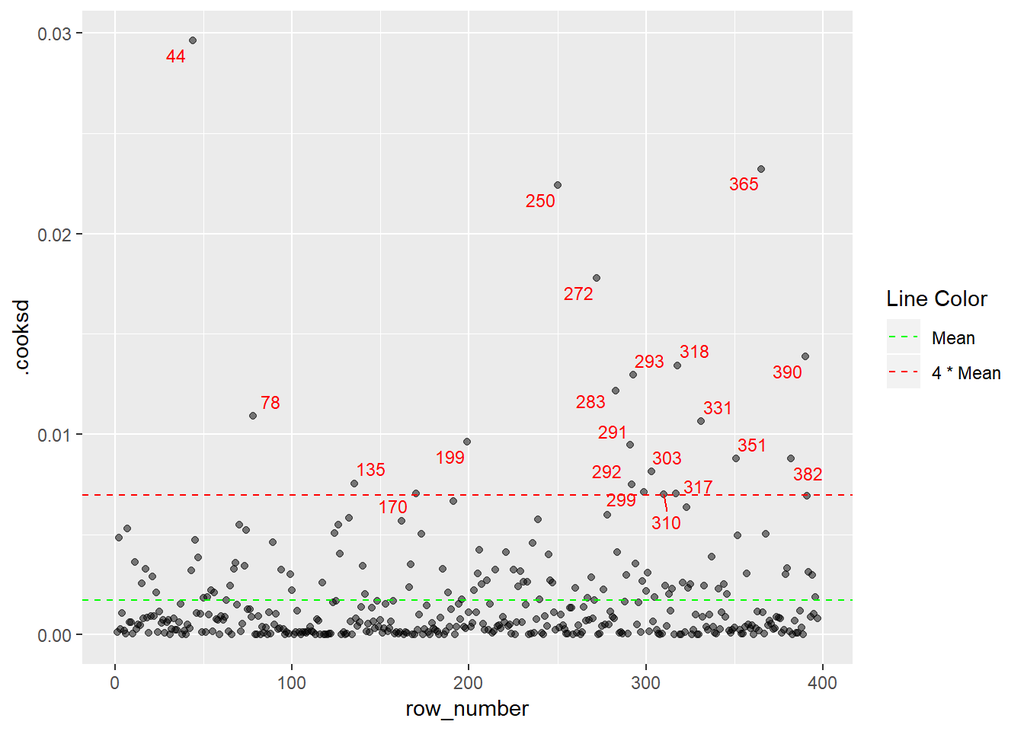

```r
ggplot(linear_mod_2_aug, aes(row_number, .cooksd)) +
  geom_point(alpha = 0.5) +
  geom_hline(aes(yintercept = mean(.cooksd), col = "green"), linetype = 2) +
  geom_hline(aes(yintercept = (4 * mean(.cooksd)), col = "red"), linetype = 2) +
  geom_text_repel(aes(label = if_else(.cooksd > (4 * mean(.cooksd)), as.character(row_number), "")),
                  col = "red", size = 3) +
  scale_color_manual("Line Color", values = c("green" = "green", "red" = "red"),
                     labels=c("Mean", "4 * Mean"))
```

```r
linear_mod_2_aug %>%
  filter(.cooksd > 4 * mean(.cooksd)) %>%
  arrange(desc(.cooksd)) %>%
  select(-c(.hat, .sigma, .se.fit, .std.resid)) %>%
  as.data.frame()
```

```
   salary discipline      rank   .fitted    .resid     .cooksd row_number
1  231545          B      Prof 133549.12  97995.88 0.029621009         44
2  205500          A      Prof 119788.16  85711.84 0.023227596        365
3  204000          A      Prof 119788.16  84211.84 0.022421721        250
4  194800          A      Prof 119788.16  75011.84 0.017790258        272
5  186023          A      Prof 119788.16  66234.84 0.013870611        390
6   67559          B      Prof 133549.12 -65990.12 0.013432043        318
7  183800          A      Prof 119788.16  64011.84 0.012955173        293
8   57800          A      Prof 119788.16 -61988.16 0.012148992        283
9  193000          B      Prof 133549.12  59450.88 0.010901864         78
10 192253          B      Prof 133549.12  58703.88 0.010629622        331
11 189409          B      Prof 133549.12  55859.88 0.009624633        199
12 174500          A      Prof 119788.16  54711.84 0.009464229        291
13 186960          B      Prof 133549.12  53410.88 0.008799210        351
14 172505          A      Prof 119788.16  52716.84 0.008786610        382
15 170500          A      Prof 119788.16  50711.84 0.008130951        303
16 168635          A      Prof 119788.16  48846.84 0.007543893        135
17 168500          A      Prof 119788.16  48711.84 0.007502252        292
18  72300          A      Prof 119788.16 -47488.16 0.007130064        299
19  71065          B AssocProf  99466.83 -28401.83 0.007050073        317
20 181257          B      Prof 133549.12  47707.88 0.007020442        170
21 166800          A      Prof 119788.16  47011.84 0.006987746        310
```

**Note:** This data should be analysed further (preferably with SME) and appropriate action should be taken before finalizing the model

##### $\color{green}{\text{residual vs fitted}}$

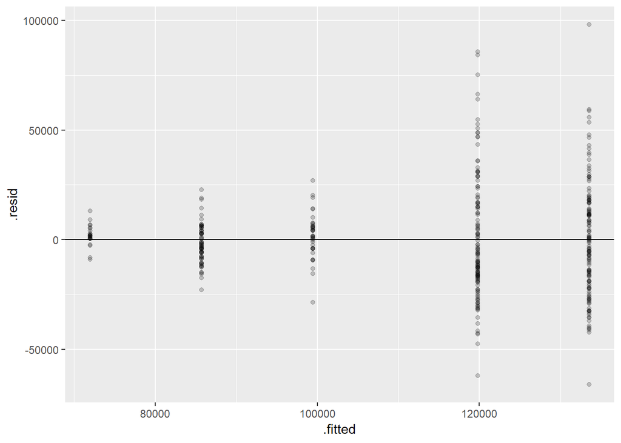

```r
ggplot(linear_mod_2_aug, aes(.fitted, .resid)) +
  geom_point(alpha = 0.2) +
  geom_hline(aes(yintercept = 0))
```

**Note:** The resid vs fitted values plot shows that the model is relatively accurate when it predicts low values of salary, and highly inaccurate when it predicts high values of salary.

#### $\color{red}{\text{Build a model to predict binary response}}$

##### $\color{green}{\text{Creating 0/1 binary indicator using salary}}$

```r
(Salaries_binary <- Salaries %>%
  mutate(salary_binary = if_else(salary < median(salary), 0 , 1)) %>%
  as.tbl())
```

```
# A tibble: 397 x 7
   rank    discipline yrs.since.phd yrs.service sex   salary salary_binary
   <fct>   <fct>              <int>       <int> <fct>  <int>         <dbl>
 1 Prof    B                     19          18 Male  139750             1
 2 Prof    B                     20          16 Male  173200             1
 3 AsstPr~ B                      4           3 Male   79750             0
 4 Prof    B                     45          39 Male  115000             1
 5 Prof    B                     40          41 Male  141500             1
 6 AssocP~ B                      6           6 Male   97000             0
 7 Prof    B                     30          23 Male  175000             1
 8 Prof    B                     45          45 Male  147765             1
 9 Prof    B                     21          20 Male  119250             1
10 Prof    B                     18          18 Fema~ 129000             1
# ... with 387 more rows
```

##### $\color{green}{\text{Splitting the data into 70% for training and 30% for testing the model}}$

```r
set.seed(1)
sample_rows <- sample(nrow(Salaries_binary), nrow(Salaries_binary) * 0.7)

Salaries_binary_train <- Salaries_binary[sample_rows,]
Salaries_binary_test <- Salaries_binary[-sample_rows,]
```

#### $\color{blue}{\text{1. Logistic Regression:}}$

```r
logistic_model <- glm(salary_binary ~ discipline + rank ,
                      data = Salaries_binary_train, family = "binomial")
```

##### $\color{green}{\text{Predicting salary_binary using test data}}$

```r
Salaries_logistic_test_out <- Salaries_binary_test %>%
  mutate(outcome_prob = predict(logistic_model, Salaries_binary_test, type = "response"),
         outcome_binary = if_else(outcome_prob > 0.5, 1, 0))
```

$\color{purple}{\text{Probability Prediction}}$

```r
Salaries_logistic_test_out %>%
  distinct(discipline, rank, outcome_prob) %>%
  spread(rank, outcome_prob)
```

```
# A tibble: 2 x 4
  discipline      AsstProf AssocProf  Prof
  <fct>              <dbl>     <dbl> <dbl>
1 A          0.00000000423    0.0683 0.603
2 B          0.0000000115     0.167  0.806
```

$\color{purple}{\text{Binary Prediction (Threshold: >0.5)}}$

```r
Salaries_logistic_test_out %>%
  distinct(discipline, rank, outcome_binary) %>%
  spread(rank, outcome_binary)
```

```
# A tibble: 2 x 4
  discipline AsstProf AssocProf  Prof
  <fct>         <dbl>     <dbl> <dbl>
1 A                 0         0     1
2 B                 0         0     1
```

##### $\color{green}{\text{Model Performance}}$

```r
confusionMatrix(as.factor(Salaries_logistic_test_out$outcome_binary),
                as.factor(Salaries_logistic_test_out$salary_binary),
                positive = "1")
```

```
Confusion Matrix and Statistics

          Reference
Prediction  0  1
         0 45  2
         1 18 55

               Accuracy : 0.8333
                 95% CI : (0.7544, 0.8951)
    No Information Rate : 0.525
    P-Value [Acc > NIR] : 1.332e-12

                  Kappa : 0.6702
 Mcnemar's Test P-Value : 0.0007962

            Sensitivity : 0.9649
            Specificity : 0.7143
         Pos Pred Value : 0.7534
         Neg Pred Value : 0.9574
             Prevalence : 0.4750
         Detection Rate : 0.4583
   Detection Prevalence : 0.6083
      Balanced Accuracy : 0.8396

       'Positive' Class : 1
```

##### $\color{green}{\text{ROC curve}}$

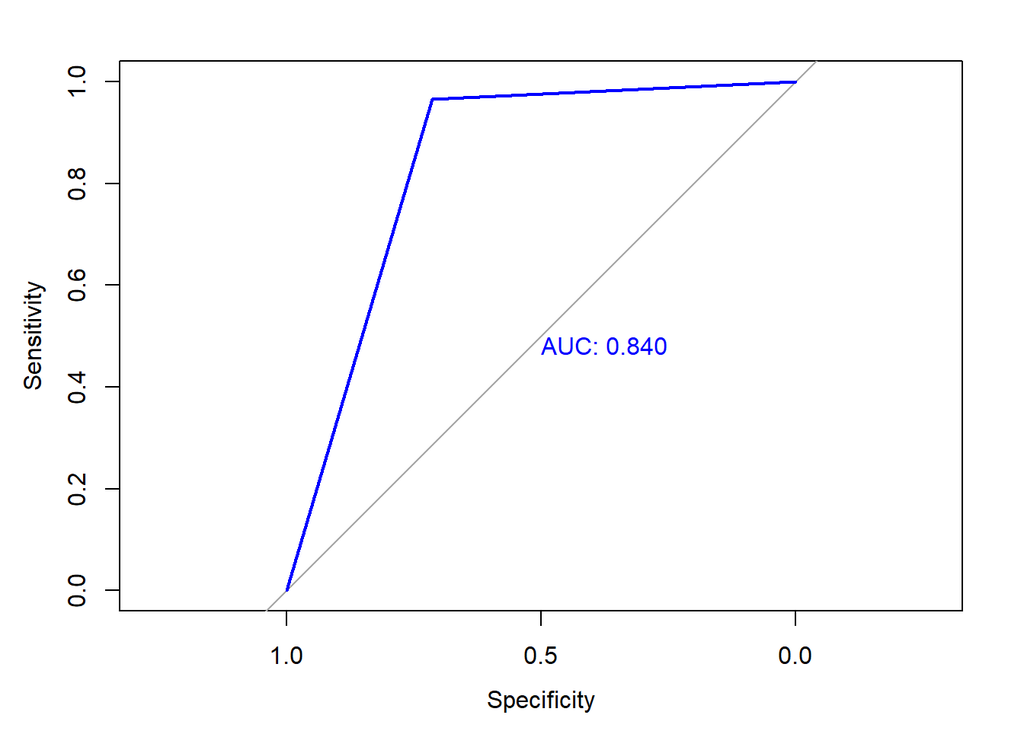

```r
logistic_model_roc <- roc(Salaries_logistic_test_out$salary_binary, Salaries_logistic_test_out$outcome_binary)
plot(logistic_model_roc, col = "blue", print.auc = TRUE)
```

#### $\color{blue}{\text{2. Decision Tree:}}$

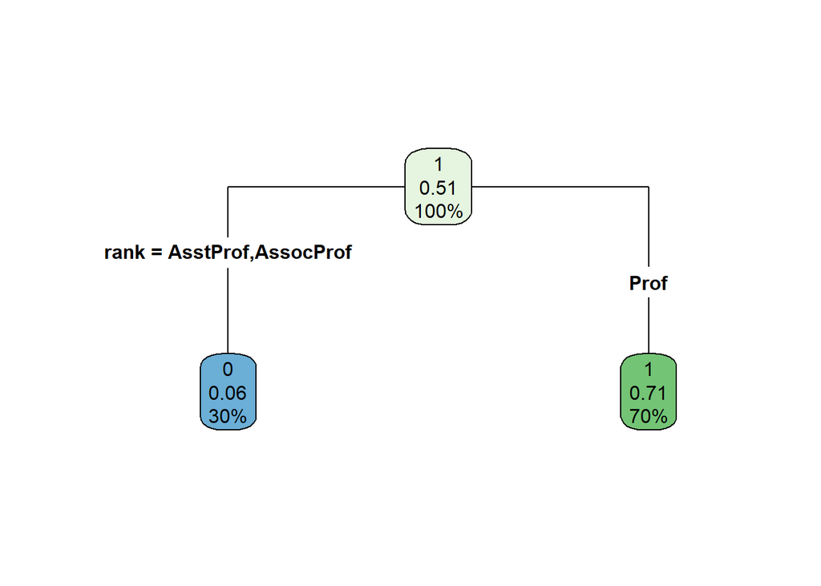

```r
decision_tree_model <- rpart(salary_binary ~ discipline + rank, data = Salaries_binary_train,
                                      method = "class", control = rpart.control(cp = 0))

rpart.plot(decision_tree_model, type = 4)
```

##### $\color{green}{\text{Predicting salary_binary using test data}}$

```r
Salaries_decisionTree_test_out <- Salaries_binary_test %>%
  mutate(outcome_binary = predict(decision_tree_model, Salaries_binary_test, type = "class"),
         outcome_binary = as.numeric(as.character(outcome_binary)))

Salaries_decisionTree_test_out %>%
  distinct(discipline, rank, outcome_binary) %>%
  spread(rank, outcome_binary)
```

```
# A tibble: 2 x 4
  discipline AsstProf AssocProf  Prof
  <fct>         <dbl>     <dbl> <dbl>
1 A                 0         0     1
2 B                 0         0     1
```

##### $\color{green}{\text{Model Performance}}$

```r
confusionMatrix(as.factor(Salaries_decisionTree_test_out$outcome_binary),
                as.factor(Salaries_decisionTree_test_out$salary_binary),
                positive = "1")
```

```
Confusion Matrix and Statistics

          Reference
Prediction  0  1
         0 45  2
         1 18 55

               Accuracy : 0.8333
                 95% CI : (0.7544, 0.8951)
    No Information Rate : 0.525
    P-Value [Acc > NIR] : 1.332e-12

                  Kappa : 0.6702
 Mcnemar's Test P-Value : 0.0007962

            Sensitivity : 0.9649
            Specificity : 0.7143
         Pos Pred Value : 0.7534
         Neg Pred Value : 0.9574
             Prevalence : 0.4750
         Detection Rate : 0.4583
   Detection Prevalence : 0.6083
      Balanced Accuracy : 0.8396

       'Positive' Class : 1
```

##### $\color{green}{\text{ROC curve}}$

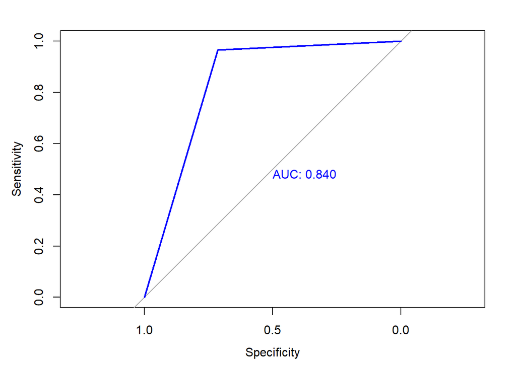

```r
decisionTree_roc <- roc(Salaries_decisionTree_test_out$salary_binary, Salaries_decisionTree_test_out$outcome_binary)
plot(decisionTree_roc, col = "blue", print.auc = TRUE)
```

#### $\color{red}{\text{Dataset Enhancement}}$

**1. State at least three research questions you would like to address and describe your thought process behind how you formulated these research questions**

1. Is the salary difference across different ethnicity and race decreasing over the last 10 years?  
   To find if the efforts to reduce ethnic and racial inequality is working or not for this profession.
2. Is Number of international papers authored/co-authored a good predictor of salary?  
   In addition to thier usual work, Professors continue to author or co-author papers/journals. Is this one of the variables used to measure their performance and does this get them a pay raise?
3. How does salary vary with the quality of benefits offered?  
   To find if there is a decreasing trend between quality of benefits offered and salary.

**2. Prepare a list of 5-7 additional attributes you would like to add to the data set. Prepare a brief explanation for each attribute**

1. ethnicity (fct) : Ethnicity of the professor
2. race (fct) : Race of the professor
3. year (num) : Year from 2009 - 2017
4. salary_year (num) : Salary corresponding to the year variable
5. international_papers_year (num) : Total number of international papers authored/co-authored corresponding to the year variable
6. vacation_days (num) : Total number of vacation days per year
7. health_insurance_quality (fct) : 1 - no insurance; 2 - poor; 3 - moderate; 4 - good; 5 - excellent
8. retirement_benefit_quality (fct) : 1 - no benefit; 2 - poor; 3 - moderate; 4 - good; 5 - excellent

**3. Estimate and justify the appropriate sample size (and sampling technique, if desired) that would be required to address the research questions you defined**

**Sampling size**  
I have no experience on this subject and my answer is based on my research on this topic.

Sample size is usually determined by the following factors:

1. Population size
2. Confidence level
3. Margin of error

There are Several available tools and methods to calculate the sample size using the above mentioned factors. One such method that i found during my research is Cochran Formula for Sample Size Calculation.

**Sampling Technique**

1. Is the salary difference across different ethnicity and race decreasing over the last 10 years?es?  
   Sampling Technique: Stratified Sampling (Groups: Ethnicity & Race)
2. Is Number of international papers authored/co-authored a good predictor of salary?  
   Sampling Technique: Random Sampling
3. How does salary vary with the quality of benefits offered?  
   Sampling Technique: Random Sampling